# Estimates of Methow Steelhead Redds and Spawners

Spawn Year 2023

Kevin See<sup>1,✉</sup>

March 26, 2024

Abstract

This report contains estimates of total steelhead redds in the Methow, after accounting for observer error. It also includes estimates of spawners, as well as prespawn mortality.

<sup>1</sup> Washington Department of Fish & Wildlife

<sup>✉</sup> Correspondence: Kevin See <Kevin.See@dfw.wa.gov>

# 1 Introduction

Redd counts are an established method to provide an index of adult spawners (Gallagher et al. 2007). In the Methow subbasin, index reaches are surveyed weekly during the steelhead spawning season (Mar 07, 2023 - Jun 02, 2023) and non-index reaches are surveyed once during the peak spawning period. The goal of this work is to:

1. Predict observer net error, using the model described in Murdoch et al. (2018).
2. Use estimates of observer net error rates and the mean survey interval to estimate the number of redds in each index reach, using a Gaussian area under the curve (GAUC) technique described in Millar et al. (2012) and Murdoch et al. (2018).
3. Estimate the total number of redds in the non-index reaches by adjusting the observed counts with the estimated net error where possible.
4. Sum the total number of estimated redds for the entire Methow subbasin.
5. Translate the estimated number of redds into estimates of spawners, by origin.

# 2 Methods

## 2.1 Net Error Model

The net error ($NE$) for a reach $i$ is defined as

$$NE_i = \frac{F_i}{V_i}$$

where $F_i$ is the number of redds the surveyor reported and $V_i$ is the true number of redds in the reach. Therefore, if we have an estimate of net error ($\hat{NE_i}$), we can calculate the true number of redds based on that estimate and the number of redds the surveyor reported:

$$\begin{equation}
V_i = \frac{F_i}{\hat{NE_i}}
\tag{2.1}
\end{equation}$$

Table 2.1: Table 2.2: Net error model covariates and coefficients.

| Term | Estimate | Std Error |
| --- | --- | --- |
| (Intercept) | -0.318 | 0.043 |
| Obs. Redd Density | 0.268 | 0.063 |
| Log Surveyor Exp. | 0.123 | 0.047 |
| Mean Thalweg CV | -0.116 | 0.051 |
| Mean Discharge | 0.109 | 0.053 |

## 2.2 Data

Redd counts were conducted on a nearly weekly basis for index reaches, and once during the peak spawning period for non-index reaches. The covariates in the observer error model of Murdoch et al. (2018) were collected during each survey. The covariate of mean thalweg CV was calculated based on all measurements taken within a reach across years (assuming this covariate does not vary through time within a reach). They were compared with the covariates contained in the model data set, as well as the estimates of net error (Figure 2.1).

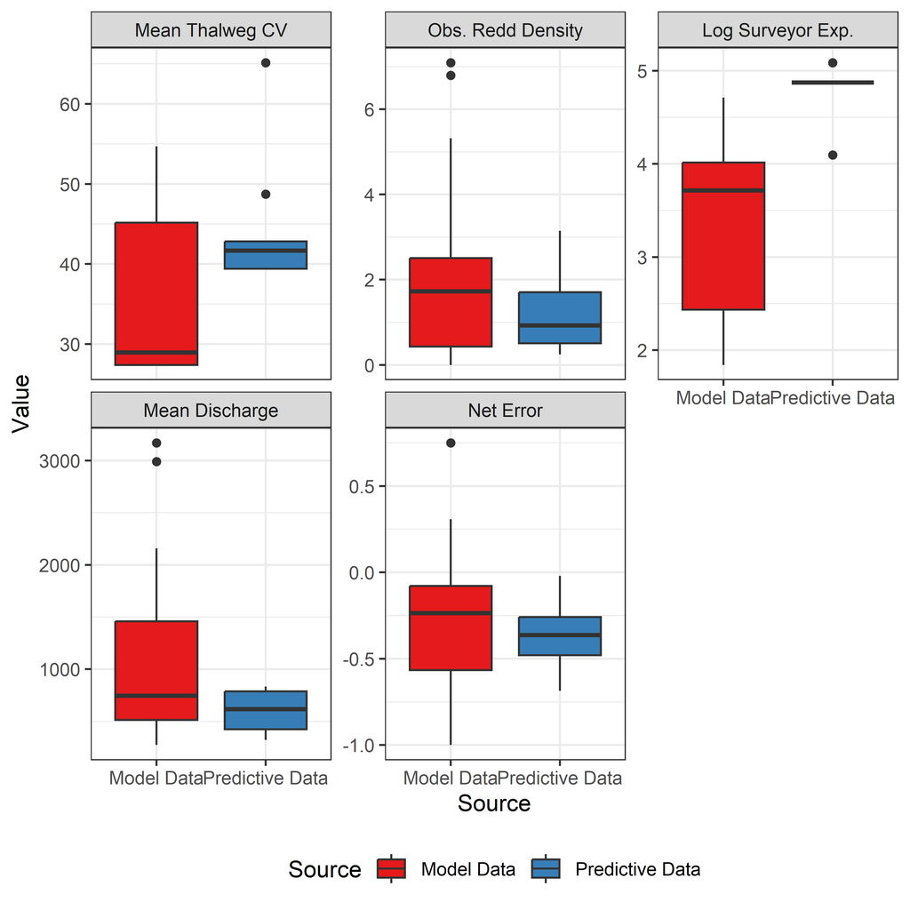

Figure 2.1: Net error covariate values. Colors correspond to either the original study (Model Data) or the surveys where the model was used in this report (Predictive Data).

Those covariates in the observer error model were collected during each survey in 2023, but predictions of net error were made for only for surveys when visible redds were present. From these survey specific estimates of net error, a mean and standard error of net error was calculated for each reach. The standard deviation was calculated by taking the square root of the sum of the squared standard errors for all predictions within a reach.

## 2.3 Estimating Redds

Use of the GAUC methodology was limited to index reaches with a minimum of two redds and at least three weeks with at least one new redd found. For those reaches, we used the method described in Millar et al. (2012) and Murdoch et al. (2018). The GAUC model was developed with spawner counts in mind. As it is usually infeasible to mark every individual spawner, only total spawner counts can be used, and an estimate of average stream life must be utilized to translate total spawner days to total unique spawners. However, in adapting this for redd surveys, we note that individual redds can be marked, and therefore the GAUC model can be fit to new redds only. The equivalent of stream life is thus the difference between survey numbers, which can be fixed at 1. We applied the average net error from all the surveys when redds were visible, so as to not bias the estimate from early weeks when no redds were found, and the observed redd density was zero.

For non-index reaches, which were surveyed only once during peak spawning, the estimate of total redds was calculated by dividing the observed redds by the estimate of net error associated with that survey (Eq. (2.1)). This assumes that no redds were washed out before the non-index survey, and that no new redds appeared after that survey. As the number of redds observed in the non-index reaches ranged from 7 to 19, any violation of this assumption should not affect the overall estimates very much. Any index reaches that did not meet the thresholds described above were treated as non-index reaches, and the total observed redds in those reaches were divided by the mean estimate of net error for each reach.

When summing reach-scale estimates to obtain estimates at the stream scale, an attempt was made to incorporate the fact that the reaches within a stream are not independent. Estimates of correlation between the reaches within a stream were made based on weekly observed redds. This method may not be perfect, since spawners could use certain reaches preferentially at different times in the season, but it may be the best we can do. Because correlations are often quite high between reaches, this is a better alternative than to naively assume the standard errors between reaches are independent of one another. These correlation estimates were combined with estimates of standard error at the reach scale to calculate a covariance matrix for the reaches within each stream, which was used when summing estimates of total redds to estimate the standard error at the stream scale. Failure to incorporate the correlations between reaches would result in an underestimate of standard error at the stream scales. Different streams (and therefore reaches in different streams) were assumed to be independent.

## 2.4 Estimating Spawners

Estimates of escapement to various tributaries in the Methow were made using a Dam Adult Branch Occupancy Model (DABOM) (Waterhouse et al. 2020) based on PIT tag detections of fish tagged at Priest Rapids dam. All fish that escaped to the various tributaries were assumed to be spawners (i.e. prespawn mortality only occurs in the mainstem). Reaches below the PIT tag arrays in some tributaries were surveyed for redds, but we assumed there was no observer error in those reaches.

To convert estimates of redds in mainstem areas into estimates of natural and hatchery spawners, the estimates of redds were multiplied by a fish per redd (FpR) estimate and then by the proportion of hatchery or wild fish. The fish per redd estimate was based on PIT tags from the branching patch-occupancy model observed to move into the lower mainstem Methow, but not into tributaries (between PTAGIS sites LMR and MRW). FpR was calculated as the ratio of male to female fish, plus 1. Reaches MRW1 - MRW8 are all in the lower mainstem Methow below Winthrop. Similarly, the proportion of hatchery and natural origin fish was calculated from the same group of PIT tags for areas in the mainstem, and the various tributaries. For reaches in tributaries below the tributary PIT tag array, FpR and the proportion hatchery were calculated based on observed PIT tags moving into the lower regions of each tributary. For the reach just below the Methow hatchery outfall, we used FpR and pHOS from Spring Creek (SCP), because they are both hatchery channels of a similar water source in close proximity to each other.

Hatchery fish were further divided into safety net (HOS-SN) and conservation (HOS-C) groups. The safety net group was defined as hatchery fish with an adipose fin clip but no coded wire tag (CWT), whereas the conservation group was defined as having a CWT. Therefore, for each spatial area, fish could be placed in one of three groups. For mainstem reaches where redd surveys were conducted, the total spawners were divided into those three groups (NOS, HOS-SN and HOS-C) based on proportions of observed PIT tags. For tributaries with existing estimates of natural origin and hatchery spawners, the hatchery spawners were divided into HOS-SN and HOS-C groups, again based on proportions from observed hatchery PIT tags.

For 2023, we noticed a discrepancy in the sex calls at Priest Rapids and the sex calls from broodstock collection at Wells Hatchery and in the Wenatchee. Therefore, we developed a correction factor that accounts for the error rate in female and male calls independently, and adjusts the fish / redd estimate accordingly. The error rate of sex calls at Priest are shown in Appendix A in Table A.1.

## 2.5 Prespawn Mortality

After translating estimates of redds to estimates of spawners by origin, we can then compare the spawner estimates to escapement estimates made using PIT tags, and estimate a prespawn mortality rate. Taking the total PIT-tag based escapement estimate, by origin, to the Methow, we then subtract any fish removed for broodstock or surplus, as well as any deaths due to harvest (Table 2.3), and then subtract the total estimate of spawners, including the tributaries, to provide an estimate of how many fish succumbed to prespawn mortality. Dividing that number by the total escapement estimate provides an estimate of the prespawn mortality rate, by origin, across the entire Methow population.

Table 2.3: Table 2.4: Known number of fish removed at particular sites for surplus or broodstock, or due to harvest, by origin.

Spawn Year

Population

Removal Location

Agency

Source

Hatchery

Natural

2023

Methow

Winthrop NFH

USFW

Adult Trapping Surplus

2023

Methow

Winthrop NFH

USFW

Brood Collections

187

53

2023

Methow

Winthrop NFH

USFW

Harvest

2023

Methow

Twisp Weir

WDFW-Methow Research Office

Adult Trapping Surplus

2023

Methow

Twisp Weir

WDFW-Methow Research Office

Brood Collections

2

10

2023

Methow

Twisp Weir

WDFW-Methow Research Office

Harvest

2023

Methow

Hook and Line; Methow River

WDFW-Methow Research Office

Adult Trapping Surplus

2023

Methow

Hook and Line; Methow River

WDFW-Methow Research Office

Brood Collections

16

0

2023

Methow

Hook and Line; Methow River

WDFW-Methow Research Office

Harvest

2023

Methow

Wells Volunteer Channel

WDFW-Methow Research Office

Adult Trapping Surplus

2023

Methow

Wells Volunteer Channel

WDFW-Methow Research Office

Brood Collections

143

0

2023

Methow

Wells Volunteer Channel

WDFW-Methow Research Office

Harvest

If either origin had a higher estimates of spawners compared to escapement, we fixed our prespawn mortality estimate at 0, reflecting a very low level of prespawn mortality. There is uncertainty in both the escapement and spawner estimates, which could explain why these types of scenarios could arise.

# 3 Results

## 3.1 Redd estimates

The estimated net error, observed redds and estimates of redds at the reach scale are shown in Table 3.1. Plots of the new redds and the GAUC fit to those data are shown in Figure 3.1. The results are summarized by major areas and population scale in Table 3.3.

Table 3.1: Table 3.2: Estimates of mean net error and redds for each reach.

River

Reach

Type

Net Error

Net Error SE

Observed Redds

Estimated Redds

Std. Err. Redds

Redds CV

Lower Methow

MRW1

Non-Index

-0.599

0.123

7

17

5.4

0.315

Lower Methow

MRW2

Index

-0.654

0.209

6

17

10.5

0.615

Lower Methow

MRW3

Non-Index

-0.31

0.111

19

28

4.4

0.159

Lower Methow

MRW4

Index

-0.26

0.111

18

24

4.9

0.206

Lower Methow

MRW5

Non-Index

-0.338

0.116

10

15

2.6

0.177

Lower Methow

MRW6

Index

-0.273

0.114

27

38

12.3

0.323

Lower Methow

MRW8

Index

-0.479

0.144

2

4

1.1

0.266

Methow Fish Hatchery

MH1

Tributary

0

0

0

0

0

Spring Creek

WN1

Tributary

0

0

23

23

8.6

0.375

Twisp

T1

Tributary

0

0

2

2

0

0

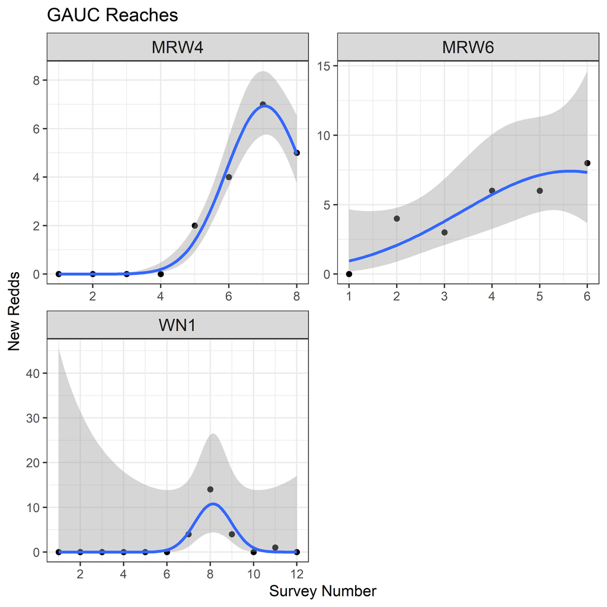

Figure 3.1: Plots of observed redd counts (black dots) through time for each qualifying index reach, and the fitted curve from the GAUC model (blue line) with associated uncertainty (gray).

Table 3.3: Table 3.4: Estimate of redds in lower mainstem Methow, and any tributaries surveyed.

River

Index

Location

# Reaches

Observed Redds

Estimated Redds

Std Err Redds

Redds CV

Lower Methow

N

Lower Methow

3

36

60

7.4

0.124

Lower Methow

Y

Lower Methow

4

53

83

26.7

0.322

Methow Fish Hatchery

Tributary

Methow Fish Hatchery

1

0

0

0

Spring Creek

Tributary

Spring Creek

1

23

23

8.6

0.375

Twisp

Tributary

Twisp

1

2

2

0

0

Total

10

114

168

29.1

0.173

## 3.2 Spawner Estimates

Demographic data about sex and origin were derived from the PIT tags detected within each area (Table 3.5.

Table 3.5: Table 3.6: Number of PIT tags detected in each area by sex and origin.

| Location | Sex | Natural | HOR-SN | HOR-C | NA |
| --- | --- | --- | --- | --- | --- |
| Lower Methow | Female | 26 | 54 | 18 | 0 |
| Lower Methow | Male | 4 | 13 | 8 | 0 |
| Upper Methow | Female | 3 | 5 | 2 | 0 |
| Upper Methow | Male | 2 | 0 | 0 | 0 |
| Chewuch | Female | 11 | 9 | 2 | 0 |
| Chewuch | Male | 2 | 2 | 0 | 0 |
| Twisp | Female | 14 | 2 | 5 | 0 |
| Twisp | Male | 6 | 2 | 0 | 0 |
| Spring Creek | Female | 0 | 7 | 10 | 0 |
| Spring Creek | Male | 0 | 1 | 4 | 0 |
| Beaver | Female | 9 | 3 | 0 | 0 |
| Beaver | Male | 2 | 1 | 0 | 1 |
| Gold | Female | 6 | 7 | 1 | 0 |
| Gold | Male | 2 | 1 | 1 | 0 |
| Libby | Female | 5 | 3 | 0 | 0 |
| Libby | Male | 1 | 1 | 0 | 0 |

Parameter estimates for fish / redd and proportion hatchery based on this PIT tag data are shown in Tables 3.7 (for areas with redd data) and 3.9 (for other areas). Fish / redd estimates in Table 3.9 are not used in the analyses presented here, but the results are made available.

Table 3.7: Table 3.8: Fish per redd and hatchery origin proportion estimates for areas with redd counts.

| Area | Fish / redd | FpR Std. Error | Prop. Hatchery | Prop Std. Error |
| --- | --- | --- | --- | --- |
| Lower Methow | 1.500 | 0.066 | 0.761 | 0.039 |
| Twisp | 1.611 | 0.071 | 0.336 | 0.090 |
| Spring Creek | 1.571 | 0.070 | 0.973 | 0.039 |

Table 3.9: Table 3.10: Fish per redd and hatchery origin proportion estimates for areas without redd surveys.

| Area | Fish / redd | FpR Std. Error | Prop. Hatchery | Prop Std. Error |
| --- | --- | --- | --- | --- |
| Upper Methow | 1.500 | 0.068 | 0.601 | 0.137 |
| Chewuch | 1.444 | 0.065 | 0.517 | 0.099 |
| Beaver | 1.600 | 0.071 | 0.346 | 0.120 |
| Gold | 1.500 | 0.065 | 0.564 | 0.113 |
| Libby | 1.429 | 0.061 | 0.424 | 0.151 |

Table 3.11 shows estimates of spawners by origin within each reach of the lower Methow, including reaches in tributaries below the PIT tag array. Combining those adjusted redd-based estimates of spawners with PIT tag-based estimates of spawners in the tributaries, Table 3.13 shows a summary of spawners by origin across various areas including the lower Methow mainstem and each tributary, as well as the population as a whole.

Table 3.11: Table 3.12: Estimates (CV) of spawners in lower Methow by reach and origin.

Location

Reach

Type

Total Spawners

Natural

HOR-SN

HOR-C

Lower Methow

MRW1

Non-Index

25 (0.32)

6 (0.36)

14 (0.33)

5 (0.36)

Lower Methow

MRW2

Index

25 (0.62)

6 (0.64)

14 (0.62)

5 (0.64)

Lower Methow

MRW3

Non-Index

42 (0.16)

10 (0.23)

23 (0.18)

9 (0.24)

Lower Methow

MRW4

Index

37 (0.21)

9 (0.26)

20 (0.23)

8 (0.27)

Lower Methow

MRW5

Non-Index

22 (0.18)

5 (0.24)

12 (0.2)

5 (0.25)

Lower Methow

MRW6

Index

57 (0.33)

14 (0.36)

31 (0.34)

12 (0.37)

Lower Methow

MRW8

Index

5 (0.27)

1 (0.31)

3 (0.28)

1 (0.32)

Methow Fish Hatchery

MH1

Tributary

0 (-)

0 (-)

0 (-)

0 (-)

Spring Creek

WN1

Tributary

36 (0.38)

0 (-)

13 (0.47)

23 (0.41)

Twisp

T1

Tributary

3 (0.04)

2 (0.13)

0 (0.47)

1 (0.41)

Total

252 (0.12)

53 (0.14)

130 (0.13)

69 (0.17)

Table 3.13: Table 3.14: Estimates (CV) of spawners by area and origin.

| River | Total Spawners | Natural | HOR-SN | HOR-C |
| --- | --- | --- | --- | --- |
| Lower Methow | 214 (0.13) | 52 (0.15) | 117 (0.13) | 45 (0.15) |
| Beaver | 108 (0.06) | 71 (0.3) | 31 (0.47) | 6 (1.01) |
| Chewuch | 168 (0.04) | 81 (0.28) | 74 (0.31) | 13 (0.71) |
| Gold | 128 (0.05) | 56 (0.34) | 58 (0.35) | 14 (0.7) |
| Libby | 75 (0.08) | 43 (0.4) | 32 (0.47) | 0 (-) |
| Methow Fish Hatchery | 0 (-) | 0 (-) | 0 (-) | 0 (-) |
| Spring Creek | 185 (0.08) | 4 (1.45) | 66 (0.3) | 115 (0.23) |
| Twisp | 188 (0.04) | 125 (0.23) | 28 (0.49) | 35 (0.43) |
| Upper Methow | 88 (0.07) | 35 (0.43) | 38 (0.45) | 15 (0.71) |
| Total | 1,154 (0.03) | 467 (0.11) | 444 (0.11) | 243 (0.15) |

## 3.3 Prespawn Mortality

The estimates of overall prespawn mortality within the Methow population, by origin, are shown in Table 3.15.

Table 3.15: Table 3.16: Methow prespawn mortality estimates. Includes estimates (standard error) of escapement, spawners, rate of prespawn mortality, and standard error of this rate, separated by origin.

| Origin | Escapement | Spawners | Prespawn Mortality | SE | CV |
| --- | --- | --- | --- | --- | --- |
| Natural | 621 (67) | 467 (53) | 0.248 | 0.117 | 0.472 |
| Hatchery | 1118 (82) | 685 (63) | 0.388 | 0.072 | 0.186 |

# 4 Discussion

Most of the covariates collected in 2023 were within the range of those in the model data set from Murdoch et al. (2018), leading to estimates of net error in a very similar range to the model dataset (Figure 2.1). However, some reaches did not meet the minimum thresholds of number of observed redds or number of weeks with at least one new redd observed, so we used the GAUC method in three out of ten reaches.

HOR-C origin steelhead PIT-tagged at Priest Rapids dam were not detected in Libby Creek this year, leading to estimates of zero spawners for those origins in that tributary (Table 3.13). Because these estimates are based on a sample of the entire Upper Columbia steelhead run, it’s possible that a low number of HOR-C steelhead may have spawned in tat tributaries, but it’s potentially more likely that the estimate of zero HOR-C steelhead spawners in those areas is correct.

# 5 Acknowledgements

The data for this report was collected by Washington Department of Fish and Wildlife, and funded by Douglas County Public Utility District.

# 6 References

Gallagher, S. P., P. K. J. Hahn, and D. H. Johnson. 2007. Salmonid field protocols handbook: Techniques for assessing status and trends in salmon and trout populations. Pages 197–234 *in* D. H. Johnson, editor. American Fisheries Society, Bethesda, Maryland.

Millar, R. B., S. McKechnie, and C. E. Jordan. 2012. Simple estimators of salmonid escapement and its variance using a new area-under-the-curve method. Canadian Journal of Fisheries and Aquatic Sciences 69(6):1002–1015. NRC Research Press.

Murdoch, A. R., C. J. Herring, C. H. Frady, K. See, and C. E. Jordan. 2018. Estimating observer error and steelhead redd abundance using a modified gaussian area-under-the-curve framework. Canadian Journal of Fisheries and Aquatic Sciences (999):1–10. NRC Research Press.

Waterhouse, L., J. White, K. See, A. Murdoch, and B. X. Semmens. 2020. [A bayesian nested patch occupancy model to estimate steelhead movement and abundance](https://doi.org/10.1002/eap.2202). Ecological Applications. Wiley Online Library.

# A Sex Errors at Priest Rapids

Fish collected for broodstock at various locations throughout the Upper Columbia (e.g. Wells Hatchery and within the Wenatchee) had a known sex. Based on PIT tag detections of this broodstock collection, those sexes could be compared with the sex call at Priest when the fish was initially tagged. Assuming that this error rate is systematic across the entire run within a brood year, we combined all tags with this kind of comparison. Table A.1 shows the sample sizes and results.

These error rates were used to adjust the counts of male and female tags within particular spawning areas before re-calculating the fish/redd estimate. For example, the adjusted number of males would be the initial number of males, minus the number of initial males times the error rate for male identification, plus the number of initial females times the error rate for female identification.

Table A.1: Table A.2: Error rate in sex calls at Priest Rapids.

| Spawn Year | Sex | N Tags | N True | N False | Perc False | Perc SE | Lower CI | Upper CI |
| --- | --- | --- | --- | --- | --- | --- | --- | --- |
| 2011 | F | 22 | 18 | 4 | 0.182 | 0.082 | 0.073 | 0.385 |
| 2011 | M | 16 | 14 | 2 | 0.125 | 0.083 | 0.035 | 0.360 |
| 2012 | F | 40 | 33 | 7 | 0.175 | 0.060 | 0.087 | 0.319 |
| 2012 | M | 20 | 19 | 1 | 0.050 | 0.049 | 0.009 | 0.236 |
| 2013 | F | 28 | 26 | 2 | 0.071 | 0.049 | 0.020 | 0.226 |
| 2013 | M | 23 | 23 | 0 | 0.000 | 0.000 | 0.000 | 0.143 |
| 2014 | F | 52 | 47 | 5 | 0.096 | 0.041 | 0.042 | 0.206 |
| 2014 | M | 55 | 53 | 2 | 0.036 | 0.025 | 0.010 | 0.123 |
| 2015 | F | 73 | 69 | 4 | 0.055 | 0.027 | 0.022 | 0.133 |
| 2015 | M | 62 | 59 | 3 | 0.048 | 0.027 | 0.017 | 0.133 |
| 2016 | F | 69 | 63 | 6 | 0.087 | 0.034 | 0.040 | 0.177 |
| 2016 | M | 66 | 65 | 1 | 0.015 | 0.015 | 0.003 | 0.081 |
| 2017 | F | 77 | 76 | 1 | 0.013 | 0.013 | 0.002 | 0.070 |
| 2017 | M | 47 | 46 | 1 | 0.021 | 0.021 | 0.004 | 0.111 |
| 2018 | F | 85 | 79 | 6 | 0.071 | 0.028 | 0.033 | 0.146 |
| 2018 | M | 79 | 77 | 2 | 0.025 | 0.018 | 0.007 | 0.088 |
| 2019 | F | 61 | 55 | 6 | 0.098 | 0.038 | 0.046 | 0.198 |
| 2019 | M | 34 | 33 | 1 | 0.029 | 0.029 | 0.005 | 0.149 |
| 2020 | F | 38 | 31 | 7 | 0.184 | 0.063 | 0.092 | 0.334 |
| 2020 | M | 33 | 31 | 2 | 0.061 | 0.042 | 0.017 | 0.196 |
| 2021 | F | 36 | 32 | 4 | 0.111 | 0.052 | 0.044 | 0.253 |
| 2021 | M | 11 | 8 | 3 | 0.273 | 0.134 | 0.097 | 0.566 |
| 2022 | F | 58 | 31 | 27 | 0.466 | 0.065 | 0.343 | 0.592 |
| 2022 | M | 21 | 21 | 0 | 0.000 | 0.000 | 0.000 | 0.155 |
| 2023 | F | 68 | 55 | 13 | 0.191 | 0.048 | 0.115 | 0.300 |
| 2023 | M | 32 | 29 | 3 | 0.094 | 0.052 | 0.032 | 0.242 |